# Homework 1 - Bartlomiej Sobieski

The aim of Homework 1 is to train a set of differently structured predictive models and evaluate their performance on a selected dataset with a binary classification task. The behaviour of these models will be explained in future homeworks.

In terms of data used in this Homework, I chose the *churn* dataset. A short summary of this dataset is included below.

Imbalance ratio: 6.07  
Number of rows: 5000  
Number of columns: 8  
Source: OpenML-CC18

The binary classification task in this dataset is based on predicting whether or not the customer churned. I have chosen this dataset as it comprises of a small and interpretable number of features, has a proper balance between the number of observations (5000) and predictive variables (8), and is not extremely imbalanced.

To show how the performance in a binary classification task can depend on model's complexity, I decided to test:

- logistic regression, a linear model with low complexity, often used as baseline in the literature
- random forest, an ensemble of decision tree classifiers that exhibits great performance on many difficult tasks
- multilayer perceptron, a simple neural network with two hidden layers of 32 neurons and relu activations that often performs on-par with many other complex models

Each model's input is properly preprocessed, i.e. logistic regression and multilayer perceptron subtract the mean from each feature and divide it by its standard deviation (estimated on the training set in each fold separately).

In addition, I have also included TabPFN - a prior-fitted network trained on a very large dataset of synthetic examples and uses the Transformer architecture.

To make sure that the performance comparison is fair, I have decided to use 5-fold crossvalidation as the evaluation procedure (with each split done in a stratified fashion to account for the imbalanced classes). In terms of metrics, I have included ROC AUC as it is a standard choice when the goal is to evaluate model's performance in general (regardless of the threshold chosen on its scores), and PR AUC (Precision-Recall) to, once again, account for the imbalance, as ROC AUC is mostly insensitive to whether the classes are balanced or not. The values of these metrics were averaged over the 5 folds used in crossvalidation. The results are presented below in the form of a bar plot with an estimated standard deviation over folds and in a purely numerical fashion to make differentiating between the models easier.

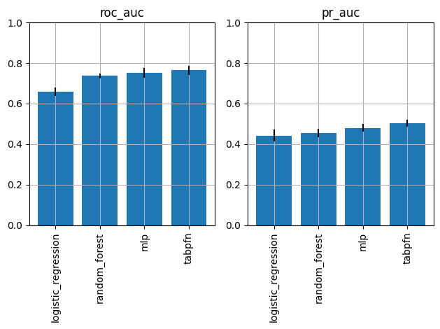

```python
make_summary_plot()
```

```python
print_metric_values()
```

```
roc_auc
name ['logistic_regression', 'random_forest', 'mlp', 'tabpfn']
mean [0.6587136171507856, 0.7374723496982029, 0.7522978630309984, 0.7639449138572105]
std [0.019801404500090772, 0.012328180089096634, 0.023127753431464424, 0.021849153717246834]


pr_auc
name ['logistic_regression', 'random_forest', 'mlp', 'tabpfn']
mean [0.4412630024265997, 0.4545836779807063, 0.48042476460988465, 0.5016909765731677]
std [0.0291945379581191, 0.020093842406755734, 0.020102977219220827, 0.01748740274117218]
```

# Appendix

## Imports

```python
import numpy as np
import pandas as pd
import matplotlib.pyplot as plt

from sklearn.linear_model import LogisticRegression
from sklearn.ensemble import RandomForestClassifier
from sklearn.neural_network import MLPClassifier
from sklearn.preprocessing import StandardScaler
from sklearn.model_selection import StratifiedKFold
from sklearn.pipeline import Pipeline
from sklearn.metrics import roc_auc_score, average_precision_score

from tabpfn import TabPFNClassifier
```

## Constants

```python
PATH_DATASET = 'https://raw.githubusercontent.com/adrianstando/imbalanced-benchmarking-set/main/datasets/churn.csv'
DATASET = pd.read_csv(PATH_DATASET, index_col = 0)
```

```python
METRICS = {
    'roc_auc': roc_auc_score,
    'pr_auc': average_precision_score}
```

```python
N_FOLDS = 5
SEED = 0
```

```python
MODELS = {
    'logistic_regression': Pipeline([
        ('standard_scaler', StandardScaler()),
        ('logistic_regression', LogisticRegression(random_state = SEED))]),
    'random_forest': RandomForestClassifier(random_state = SEED),
    'mlp': Pipeline([
        ('standard_scaler', StandardScaler()),
        ('mlp', MLPClassifier((32, 32), 'relu', random_state = SEED))]),
    'tabpfn': TabPFNClassifier(seed = SEED)}
```

```
Loading model that can be used for inference only
Using a Transformer with 25.82 M parameters
```

## Functions

```python
def train_models_with_stratifed_cv():
    dataset_npy = DATASET.values
    x, y = dataset_npy[:, :-1], dataset_npy[:, -1]
    stratif_cv = StratifiedKFold(n_splits = N_FOLDS)
    results = {
        fold_id: {
            model_name: {metric_name: None} for metric_name in METRICS.keys()
            for model_name in MODELS.keys()} for fold_id in range(N_FOLDS)}
    for fold_id, (train_ids, val_ids) in enumerate(stratif_cv.split(x, y)):
        print(f'Fold: {fold_id}')
        x_train, x_val = x[train_ids], x[val_ids]
        y_train, y_val = y[train_ids], y[val_ids]
        for model_name, model in MODELS.items():
            print(f'Training {model_name}')
            if model_name == 'tabpfn':
                model.fit(x_train, y_train, overwrite_warning = True)
            else:
                model.fit(x_train, y_train)
            print(f'Validation')
            y_pred = model.predict_proba(x_val)[:, -1]
            for metric_name, metric in METRICS.items():
                results[fold_id][model_name][metric_name] = metric(y_val, y_pred)
    print('Finished')
    return results
```

## Experiment

```python
results = train_models_with_stratifed_cv()
```

```
Fold: 0
Training logistic_regression
Validation
Training random_forest
Validation
Training mlp
```

```
Validation
Training tabpfn
Validation
```

```
Fold: 1
Training logistic_regression
Validation
Training random_forest
Validation
Training mlp
```

```
Validation
Training tabpfn
Validation
Fold: 2
Training logistic_regression
Validation
Training random_forest
Validation
Training mlp
```

```
Validation
Training tabpfn
Validation
Fold: 3
Training logistic_regression
Validation
Training random_forest
Validation
Training mlp
```

```
Validation
Training tabpfn
Validation
Fold: 4
Training logistic_regression
Validation
Training random_forest
Validation
Training mlp
```

```
Validation
Training tabpfn
Validation
Finished
```

```python
results
```

```
{0: {'logistic_regression': {'pr_auc': 0.4795314326357829,
   'roc_auc': 0.6697380262386579},
  'random_forest': {'pr_auc': 0.4601264758594199,
   'roc_auc': 0.7181243240119222},
  'mlp': {'pr_auc': 0.4726315756721595, 'roc_auc': 0.7160395974207184},
  'tabpfn': {'pr_auc': 0.5131782508057409, 'roc_auc': 0.7301744565262263}},
 1: {'logistic_regression': {'pr_auc': 0.39962925221044693,
   'roc_auc': 0.6286792328206143},
  'random_forest': {'pr_auc': 0.42458101895801703,
   'roc_auc': 0.7350498270296155},
  'mlp': {'pr_auc': 0.46454771005403805, 'roc_auc': 0.7627209603778102},
  'tabpfn': {'pr_auc': 0.4776494842130937, 'roc_auc': 0.7811243487809509}},
 2: {'logistic_regression': {'pr_auc': 0.44956502736172094,
   'roc_auc': 0.6878606989819929},
  'random_forest': {'pr_auc': 0.43960480391785056,
   'roc_auc': 0.743347451679753},
  'mlp': {'pr_auc': 0.470626905579468, 'roc_auc': 0.7483136419554323},
  'tabpfn': {'pr_auc': 0.4897140858773184, 'roc_auc': 0.7606155929292677}},
 3: {'logistic_regression': {'pr_auc': 0.41662875070931343,
   'roc_auc': 0.649405758560688},
  'random_forest': {'pr_auc': 0.46775106988844506,
   'roc_auc': 0.7558808562329689},
  'mlp': {'pr_auc': 0.47422653703465756, 'roc_auc': 0.7870908434288717},
  'tabpfn': {'pr_auc': 0.500267815044805, 'roc_auc': 0.7931645818969764}},
 4: {'logistic_regression': {'pr_auc': 0.4609605492157347,
   'roc_auc': 0.6578843691519747},
  'random_forest': {'pr_auc': 0.48085502127979873,
   'roc_auc': 0.7349592895367544},
  'mlp': {'pr_auc': 0.5200910947091001, 'roc_auc': 0.7473242719721593},
  'tabpfn': {'pr_auc': 0.5276452469248808, 'roc_auc': 0.7546455891526315}}}
```

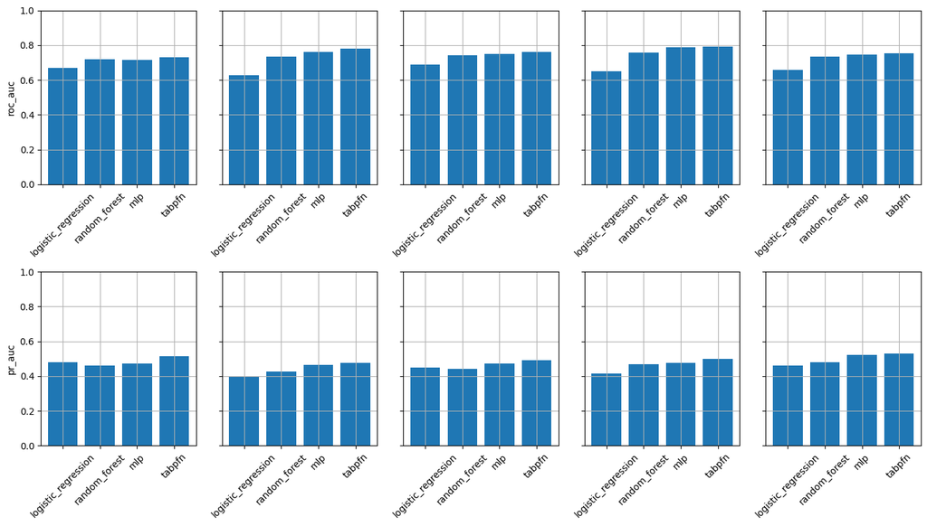

```python
fig, axs = plt.subplots(
    len(METRICS),
    N_FOLDS,
    figsize = (14, 8),
    sharey = True)

for metric_id, metric_name in enumerate(METRICS.keys()):
    for fold_id in range(N_FOLDS):
        names = results[fold_id].keys()
        values = [results[fold_id][model_name][metric_name]
                  for model_name in MODELS.keys()]
        ax = axs[metric_id, fold_id]
        ax.grid()
        ax.bar(names, values)
        ax.set_ylim(0, 1)
        ax.tick_params(axis = 'x', labelrotation = 45)
        if fold_id == 0:
            ax.set_ylabel(metric_name)
plt.tight_layout()
plt.show()
```

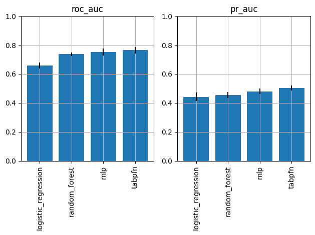

```python
def make_summary_plot():
        fig, axs = plt.subplots(1, len(METRICS))

        metrics_aggr = {}

        for metric_id, metric_name in enumerate(METRICS.keys()):
                names = results[fold_id].keys()
                values = [np.mean([results[fold_id][model_name][metric_name]
                                for fold_id in range(N_FOLDS)])
                                for model_name in MODELS.keys()]
                errors = [np.std([results[fold_id][model_name][metric_name]
                                for fold_id in range(N_FOLDS)])
                                for model_name in MODELS.keys()]
                metrics_aggr[metric_name] = {'name': names, 'mean': values, 'std': errors}
                ax = axs[metric_id]
                ax.bar(names, values, yerr = errors)
                ax.set_ylim(0, 1)
                ax.tick_params(axis = 'x', rotation = 90)
                ax.set_title(metric_name)
                ax.grid()
        plt.tight_layout()
        plt.show()
make_summary_plot()
```

```python
def print_metric_values():
    for metric_name in metrics_aggr.keys():
        print(metric_name)
        for k in metrics_aggr[metric_name].keys():
            print(f'{k} {list(metrics_aggr[metric_name][k])}')
        print('\n')
print_metric_values()
```

```
roc_auc
name ['logistic_regression', 'random_forest', 'mlp', 'tabpfn']
mean [0.6587136171507856, 0.7374723496982029, 0.7522978630309984, 0.7639449138572105]
std [0.019801404500090772, 0.012328180089096634, 0.023127753431464424, 0.021849153717246834]


pr_auc
name ['logistic_regression', 'random_forest', 'mlp', 'tabpfn']
mean [0.4412630024265997, 0.4545836779807063, 0.48042476460988465, 0.5016909765731677]
std [0.0291945379581191, 0.020093842406755734, 0.020102977219220827, 0.01748740274117218]
```